# BHao_HW5

## 8.1 Figure 8.24 shows the ACFs for 36 random numbers, 360 random numbers and for 1,000 random numbers.

### 8.1.a. Explain the differences among these figures. Do they all indicate the data are white noise?

The differences between the three figures is the number of random values used, 36, 360 and 1000, respectively. Yes, all figures indicate the data are white noise because there are no significant spikes?

### 8.1.b. Why are the critical values at different distances from the mean of zero? Why are the autocorrelations different in each figure when they each refer to white noise?

When there are more random values, the closer the critical values are to the mean of zero. I assume the reason is similar to why standard errors decrease with the number of observations. Each figure refers to white noise, the when the range of random values is wider, the lower the autocorrelations between the values.

## 8.2 A classic example of a non-stationary series is the daily closing IBM stock prices (data set ibmclose). Use R to plot the daily closing prices for IBM stock and the ACF and PACF. Explain how each plot shows the series is non-stationary and should be differenced.

The plot of IBM’s closing price shows a downward trend. The ACF plot shows significant autocorrelation between values and their lagged counterparts. The PACF plot shows the correlation between values and their lagged counterparts but with the effects of the in-between values removed. The downward trend and significant autocorrelation in the ACF chart indicate that the series is non-stationary and should be differenced.

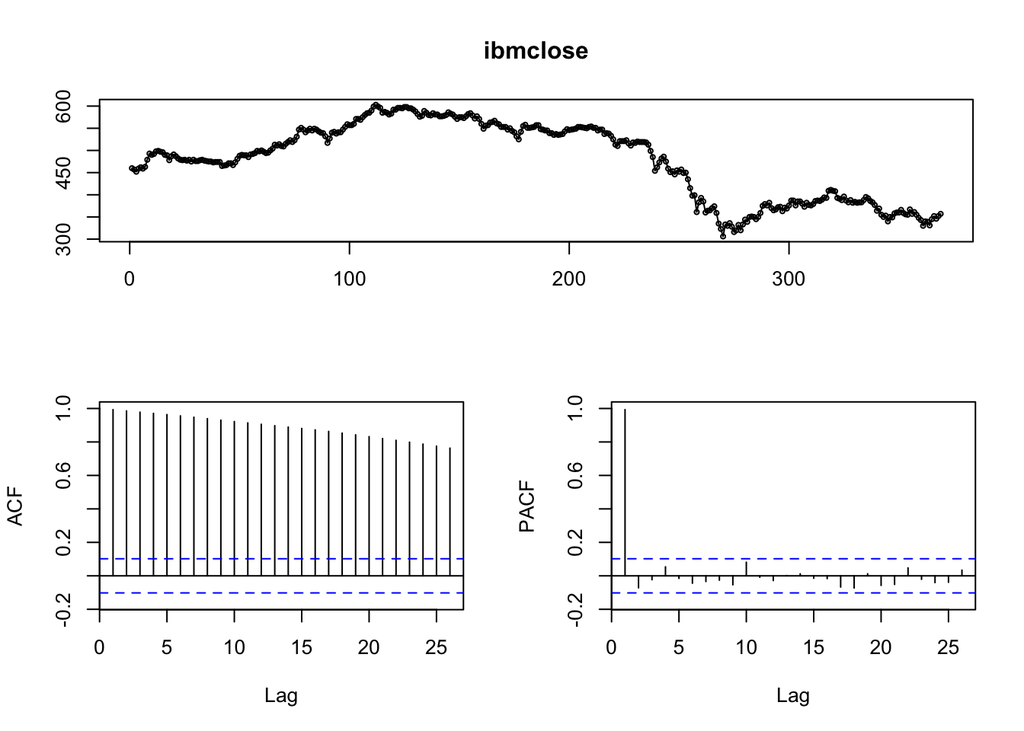

```r
tsdisplay(ibmclose)
```

## 8.6 Consider the number of women murdered each year (per 100,000 standard population) in the United States (data set wmurders).

### 8.6.a. By studying appropriate graphs of the series in R, find an appropriate ARIMA(p,d,q) model for these data.

The data are clearly non-stationary as it trends up and then down over a long period of time; thus, we take the first difference which looks stationary.

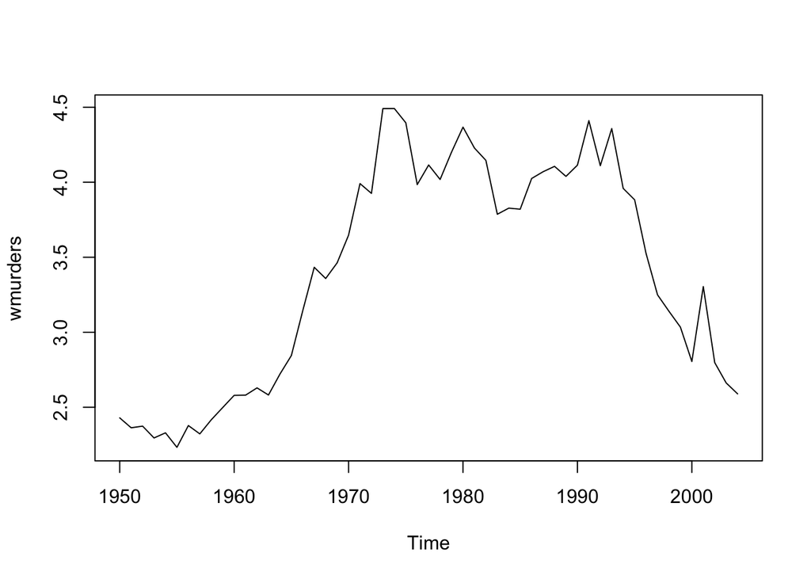

```r
plot(wmurders)
```

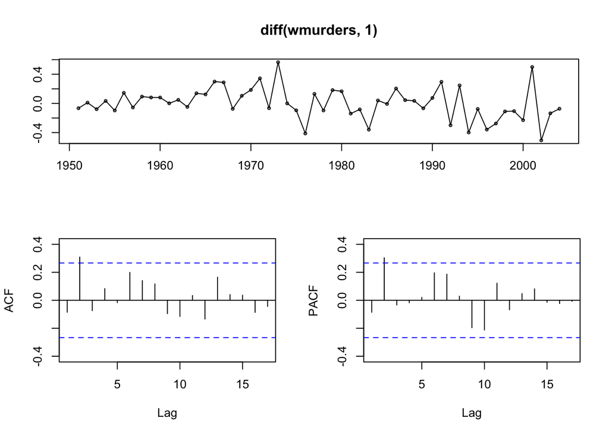

```r
tsdisplay(diff(wmurders, 1))
```

The spike in lag2 of both ACF and PACF suggest evaluating ARIMA(2,1,0) and ARIMA(0,1,2) models along with a few similar variants. Based on the table below, the ARIMA(0,1,3) model produced the lowest AICc.

```r
fit310 = Arima(diff(wmurders, 1), order=c(3,1,0))
fit210 = Arima(diff(wmurders, 1), order=c(2,1,0))
fit211 = Arima(diff(wmurders, 1), order=c(2,1,1))
fit112 = Arima(diff(wmurders, 1), order=c(1,1,2))
fit012 = Arima(diff(wmurders, 1), order=c(0,1,2))
fit013 = Arima(diff(wmurders, 1), order=c(0,1,3))

model = c('fit310', 'fit210', 'fit211', 'fit112', 'fit012', 'fit013')
aicc = c(fit310$aicc, fit210$aicc, fit211$aicc, fit112$aicc, fit012$aicc, fit013$aicc)
data.frame(model, aicc) %>% arrange(aicc)
```

```
##    model       aicc
## 1 fit013 -6.7025402
## 2 fit211 -6.2849522
## 3 fit112 -5.9200269
## 4 fit012 -5.5729355
## 5 fit210 -0.1881222
## 6 fit310  0.8147690
```

### 8.6.b. Should you include a constant in the model? Explain.

No, when d >= 1 then c should be set to zero.

### 8.6.c. Write this model in terms of the backshift operator.

```r
summary(fit013)
```

```
## Series: diff(wmurders, 1)
## ARIMA(0,1,3)
##
## Coefficients:
##           ma1     ma2      ma3
##       -1.0154  0.4324  -0.3217
## s.e.   0.1282  0.2278   0.1737
##
## sigma^2 estimated as 0.04475:  log likelihood=7.77
## AIC=-7.54   AICc=-6.7   BIC=0.35
##
## Training set error measures:
##                       ME      RMSE       MAE       MPE     MAPE      MASE
## Training set -0.01357123 0.2035513 0.1558588 -60.29729 252.6864 0.6680611
##                    ACF1
## Training set -0.0319213
```